## Ayudantía N°1

Estudiante: Valentina Andrade

Magíster Economía PUC

## Parte 1. Vectores y matrices

1. Genere tres variables escalares

```matlab
a = 1
```

a = 1

```matlab
b = 8
```

b = 8

```matlab
c = 10
```

c = 10

```matlab
v1 = [a,b,c]
```

v1 = 1×3

1 8 10

```matlab
%% Primera forma (transpose columns v1)
v2_1 = [a,b,c]'
```

1 8 10

```matlab
%% Segunda forma (def rows)
v2_2 = [a;b;c]
```

1 8 10

```matlab
%%First - array
v3_1 = [1,2,3 ;2,16,8;1,20,10]
```

1 2 3 2 16 8 1 20 10

```matlab
%% Second
v3_2 = [1 2 3
    2 16 20
    1 8 10]
```

1 2 3 2 16 20 1 8 10

```matlab
%% Third - array
v3 = [1:3 ; 2 16 20; 1 8 10]
```

v3 = 3×3

1 2 3 2 16 20 1 8 10

5. Genere matrices 4x4 llamadas $V_4$

```matlab
v4 = zeros(4)
```

v4 = 4×4

0 0 0 0 0 0 0 0 0 0 0 0 0 0 0 0

```matlab
v5 = ones(4)
```

v5 = 4×4

1 1 1 1 1 1 1 1 1 1 1 1 1 1 1 1

```matlab
v6 = diag(linspace(1,1,4))
```

v6 = 4×4

1 0 0 0 0 1 0 0 0 0 1 0 0 0 0 1

```matlab
v7 = randi([8,8],4)
```

v7 = 4×4

8 8 8 8 8 8 8 8 8 8 8 8 8 8 8 8

6. Genere los siguientes conjuntos escogiendo de V3: A=la segunda columna, B=el elemento (3,2), C=los elementos 1,4,5

```matlab
A = v3(:,2)
```

A = 3×1

2 16 8

```matlab
B = v3(3,2)
```

B = 8

```matlab
C = v3([1, 4, 5])
```

C = 1×3

1 2 16

7. Generee Z de dos formas diferentes

```matlab
z1 = 1:1:100
```

z1 = 1×100

1 2 3 4 5 6 7 8 9 10 11 12 13 14 15 16 17 18 19 20 21 22 23 24 25 26 27 28 29 30 31 32 33 34 35 36 37 38 39 40 41 42 43 44 45 46 47 48 49 50

```matlab
z2 = linspace(1,100)
```

z2 = 1×100

1 2 3 4 5 6 7 8 9 10 11 12 13 14 15 16 17 18 19 20 21 22 23 24 25 26 27 28 29 30 31 32 33 34 35 36 37 38 39 40 41 42 43 44 45 46 47 48 49 50

8. Genere un vector W de 100 números aleatorios entre 0 y 1

```matlab
w = randi((0:1), 1, 100)
```

w = 1×100

0 1 1 1 1 0 1 1 1 1 1 0 1 0 1 0 0 0 0 1 1 0 1 0 0 0 1 1 0 0 0 1 1 1 0 1 1 0 0 0 1 0 1 0 1 0 1 1 1 1

## Parte 2. Distribuciones de probabilidad

```matlab
clc
clear
```

0. Parámetros (row and column)

```matlab
r = 1000
```

r = 1000

```matlab
c = 1
```

c = 1

```matlab
x = rand(r,c)
```

x = 1000×1

0.5383 0.9961 0.0782 0.4427 0.1067 0.9619 0.0046 0.7749 0.8173 0.8687

```matlab
x_i = randn(r,c)
```

x_i = 1000×1

-1.6338 0.7612 1.1933 1.6321 -1.5322 -1.3369 -1.4738 -0.0417 -0.6155 1.3142

1.Distribución uniforme x1 ~ U(1,4)

x1 debe distribuir uniforme donde a = 1, b = 4,

```matlab
x1 = x*(4-1)+1
```

x1 = 1000×1

2.6150 3.9884 1.2345 2.3280 1.3200 3.8857 1.0139 3.3247 3.4519 3.6061

2. Distribución chi cuadrado

```matlab
x2 = 3*(x_i.^2)
```

x2 = 1000×1

8.0079 1.7383 4.2719 7.9908 7.0428 5.3615 6.5167 0.0052 1.1365 5.1810

3. Distribución t student

x3 t student 2 gl

```matlab
x3a = 0;
for i = 1:2
    x3a = x3a + randn(r,c).^2;
    i = i+1;
end

x3 = x_i./sqrt(x3a/2)
```

x3 = 1000×1

-2.7176 2.0023 0.7719 5.1648 -7.9591 -1.4182 -1.9307 -0.0657 -0.5532 1.0392

4. Distribución normal

x4: números aleatorios con distribución normal, con media 5 y desvío 1.5 (con randn)

```matlab
x4 = x_i*1.5+5
```

x4 = 1000×1

2.5493 6.1418 6.7900 7.4481 2.7017 2.9947 2.7892 4.9375 4.0767 6.9712

5. Partición de muestra

X5: mixtura de variables utilizando X3 y X4. La mixtura en este caso es una distribucion en

donde un 50% de los casos se comporta como X3 y el 50% restante como X4. Para generar esta distribución utilizaré mi variable aleatoria adicional (x) y a partir de ella seleccionaré una muestra dpnde con un 50% de probabilidad se recupere el valor de x3 o en caso contrarop x4

```matlab
x5 = zeros(r,c);

for i = 1:r
    if x (i,1) < 0.5
        x5(i,1) = x3 (i, 1);
    else x5 (i) = x4 (i,1);
    end
    i = i+1
end;
```

i = 4

i = 5

i = 6

i = 7

i = 8

i = 9

i = 10

i = 11

i = 12

i = 13

i = 14

i = 15

i = 16

i = 17

i = 18

i = 19

i = 20

i = 21

i = 22

i = 23

i = 24

i = 25

i = 26

i = 27

i = 28

i = 29

i = 30

i = 31

i = 32

i = 33

i = 34

i = 35

i = 36

i = 37

i = 38

i = 39

i = 40

i = 41

i = 42

i = 43

i = 44

i = 45

i = 46

i = 47

i = 48

i = 49

i = 50

i = 51

i = 52

i = 53

i = 54

i = 55

i = 56

i = 57

i = 58

i = 59

i = 60

i = 61

i = 62

i = 63

i = 64

i = 65

i = 66

i = 67

i = 68

i = 69

i = 70

i = 71

i = 72

i = 73

i = 74

i = 75

i = 76

i = 77

i = 78

i = 79

i = 80

i = 81

i = 82

i = 83

i = 84

i = 85

i = 86

i = 87

i = 88

i = 89

i = 90

i = 91

i = 92

i = 93

i = 94

i = 95

i = 96

i = 97

i = 98

i = 99

i = 100

i = 101

i = 102

i = 103

i = 104

i = 105

i = 106

i = 107

i = 108

i = 109

i = 110

i = 111

i = 112

i = 113

i = 114

i = 115

i = 116

i = 117

i = 118

i = 119

i = 120

i = 121

i = 122

i = 123

i = 124

i = 125

i = 126

i = 127

i = 128

i = 129

i = 130

i = 131

i = 132

i = 133

i = 134

i = 135

i = 136

i = 137

i = 138

i = 139

i = 140

i = 141

i = 142

i = 143

i = 144

i = 145

i = 146

i = 147

i = 148

i = 149

i = 150

i = 151

i = 152

i = 153

i = 154

i = 155

i = 156

i = 157

i = 158

i = 159

i = 160

i = 161

i = 162

i = 163

i = 164

i = 165

i = 166

i = 167

i = 168

i = 169

i = 170

i = 171

i = 172

i = 173

i = 174

i = 175

i = 176

i = 177

i = 178

i = 179

i = 180

i = 181

i = 182

i = 183

i = 184

i = 185

i = 186

i = 187

i = 188

i = 189

i = 190

i = 191

i = 192

i = 193

i = 194

i = 195

i = 196

i = 197

i = 198

i = 199

i = 200

i = 201

i = 202

i = 203

i = 204

i = 205

i = 206

i = 207

i = 208

i = 209

i = 210

i = 211

i = 212

i = 213

i = 214

i = 215

i = 216

i = 217

i = 218

i = 219

i = 220

i = 221

i = 222

i = 223

i = 224

i = 225

i = 226

i = 227

i = 228

i = 229

i = 230

i = 231

i = 232

i = 233

i = 234

i = 235

i = 236

i = 237

i = 238

i = 239

i = 240

i = 241

i = 242

i = 243

i = 244

i = 245

i = 246

i = 247

i = 248

i = 249

i = 250

i = 251

i = 252

i = 253

i = 254

i = 255

i = 256

i = 257

i = 258

i = 259

i = 260

i = 261

i = 262

i = 263

i = 264

i = 265

i = 266

i = 267

i = 268

i = 269

i = 270

i = 271

i = 272

i = 273

i = 274

i = 275

i = 276

i = 277

i = 278

i = 279

i = 280

i = 281

i = 282

i = 283

i = 284

i = 285

i = 286

i = 287

i = 288

i = 289

i = 290

i = 291

i = 292

i = 293

i = 294

i = 295

i = 296

i = 297

i = 298

i = 299

i = 300

i = 301

i = 302

i = 303

i = 304

i = 305

i = 306

i = 307

i = 308

i = 309

i = 310

i = 311

i = 312

i = 313

i = 314

i = 315

i = 316

i = 317

i = 318

i = 319

i = 320

i = 321

i = 322

i = 323

i = 324

i = 325

i = 326

i = 327

i = 328

i = 329

i = 330

i = 331

i = 332

i = 333

i = 334

i = 335

i = 336

i = 337

i = 338

i = 339

i = 340

i = 341

i = 342

i = 343

i = 344

i = 345

i = 346

i = 347

i = 348

i = 349

i = 350

i = 351

i = 352

i = 353

i = 354

i = 355

i = 356

i = 357

i = 358

i = 359

i = 360

i = 361

i = 362

i = 363

i = 364

i = 365

i = 366

i = 367

i = 368

i = 369

i = 370

i = 371

i = 372

i = 373

i = 374

i = 375

i = 376

i = 377

i = 378

i = 379

i = 380

i = 381

i = 382

i = 383

i = 384

i = 385

i = 386

i = 387

i = 388

i = 389

i = 390

i = 391

i = 392

i = 393

i = 394

i = 395

i = 396

i = 397

i = 398

i = 399

i = 400

i = 401

i = 402

i = 403

i = 404

i = 405

i = 406

i = 407

i = 408

i = 409

i = 410

i = 411

i = 412

i = 413

i = 414

i = 415

i = 416

i = 417

i = 418

i = 419

i = 420

i = 421

i = 422

i = 423

i = 424

i = 425

i = 426

i = 427

i = 428

i = 429

i = 430

i = 431

i = 432

i = 433

i = 434

i = 435

i = 436

i = 437

i = 438

i = 439

i = 440

i = 441

i = 442

i = 443

i = 444

i = 445

i = 446

i = 447

i = 448

i = 449

i = 450

i = 451

i = 452

i = 453

i = 454

i = 455

i = 456

i = 457

i = 458

i = 459

i = 460

i = 461

i = 462

i = 463

i = 464

i = 465

i = 466

i = 467

i = 468

i = 469

i = 470

i = 471

i = 472

i = 473

i = 474

i = 475

i = 476

i = 477

i = 478

i = 479

i = 480

i = 481

i = 482

i = 483

i = 484

i = 485

i = 486

i = 487

i = 488

i = 489

i = 490

i = 491

i = 492

i = 493

i = 494

i = 495

i = 496

i = 497

i = 498

i = 499

i = 500

i = 501

i = 502

i = 503

i = 504

i = 505

i = 506

i = 507

i = 508

i = 509

i = 510

i = 511

i = 512

i = 513

i = 514

i = 515

i = 516

i = 517

i = 518

i = 519

i = 520

i = 521

i = 522

i = 523

i = 524

i = 525

i = 526

i = 527

i = 528

i = 529

i = 530

i = 531

i = 532

i = 533

i = 534

i = 535

i = 536

i = 537

i = 538

i = 539

i = 540

i = 541

i = 542

i = 543

i = 544

i = 545

i = 546

i = 547

i = 548

i = 549

i = 550

i = 551

i = 552

i = 553

i = 554

i = 555

i = 556

i = 557

i = 558

i = 559

i = 560

i = 561

i = 562

i = 563

i = 564

i = 565

i = 566

i = 567

i = 568

i = 569

i = 570

i = 571

i = 572

i = 573

i = 574

i = 575

i = 576

i = 577

i = 578

i = 579

i = 580

i = 581

i = 582

i = 583

i = 584

i = 585

i = 586

i = 587

i = 588

i = 589

i = 590

i = 591

i = 592

i = 593

i = 594

i = 595

i = 596

i = 597

i = 598

i = 599

i = 600

i = 601

i = 602

i = 603

i = 604

i = 605

i = 606

i = 607

i = 608

i = 609

i = 610

i = 611

i = 612

i = 613

i = 614

i = 615

i = 616

i = 617

i = 618

i = 619

i = 620

i = 621

i = 622

i = 623

i = 624

i = 625

i = 626

i = 627

i = 628

i = 629

i = 630

i = 631

i = 632

i = 633

i = 634

i = 635

i = 636

i = 637

i = 638

i = 639

i = 640

i = 641

i = 642

i = 643

i = 644

i = 645

i = 646

i = 647

i = 648

i = 649

i = 650

i = 651

i = 652

i = 653

i = 654

i = 655

i = 656

i = 657

i = 658

i = 659

i = 660

i = 661

i = 662

i = 663

i = 664

i = 665

i = 666

i = 667

i = 668

i = 669

i = 670

i = 671

i = 672

i = 673

i = 674

i = 675

i = 676

i = 677

i = 678

i = 679

i = 680

i = 681

i = 682

i = 683

i = 684

i = 685

i = 686

i = 687

i = 688

i = 689

i = 690

i = 691

i = 692

i = 693

i = 694

i = 695

i = 696

i = 697

i = 698

i = 699

i = 700

i = 701

i = 702

i = 703

i = 704

i = 705

i = 706

i = 707

i = 708

i = 709

i = 710

i = 711

i = 712

i = 713

i = 714

i = 715

i = 716

i = 717

i = 718

i = 719

i = 720

i = 721

i = 722

i = 723

i = 724

i = 725

i = 726

i = 727

i = 728

i = 729

i = 730

i = 731

i = 732

i = 733

i = 734

i = 735

i = 736

i = 737

i = 738

i = 739

i = 740

i = 741

i = 742

i = 743

i = 744

i = 745

i = 746

i = 747

i = 748

i = 749

i = 750

i = 751

i = 752

i = 753

i = 754

i = 755

i = 756

i = 757

i = 758

i = 759

i = 760

i = 761

i = 762

i = 763

i = 764

i = 765

i = 766

i = 767

i = 768

i = 769

i = 770

i = 771

i = 772

i = 773

i = 774

i = 775

i = 776

i = 777

i = 778

i = 779

i = 780

i = 781

i = 782

i = 783

i = 784

i = 785

i = 786

i = 787

i = 788

i = 789

i = 790

i = 791

i = 792

i = 793

i = 794

i = 795

i = 796

i = 797

i = 798

i = 799

i = 800

i = 801

i = 802

i = 803

i = 804

i = 805

i = 806

i = 807

i = 808

i = 809

i = 810

i = 811

i = 812

i = 813

i = 814

i = 815

i = 816

i = 817

i = 818

i = 819

i = 820

i = 821

i = 822

i = 823

i = 824

i = 825

i = 826

i = 827

i = 828

i = 829

i = 830

i = 831

i = 832

i = 833

i = 834

i = 835

i = 836

i = 837

i = 838

i = 839

i = 840

i = 841

i = 842

i = 843

i = 844

i = 845

i = 846

i = 847

i = 848

i = 849

i = 850

i = 851

i = 852

i = 853

i = 854

i = 855

i = 856

i = 857

i = 858

i = 859

i = 860

i = 861

i = 862

i = 863

i = 864

i = 865

i = 866

i = 867

i = 868

i = 869

i = 870

i = 871

i = 872

i = 873

i = 874

i = 875

i = 876

i = 877

i = 878

i = 879

i = 880

i = 881

i = 882

i = 883

i = 884

i = 885

i = 886

i = 887

i = 888

i = 889

i = 890

i = 891

i = 892

i = 893

i = 894

i = 895

i = 896

i = 897

i = 898

i = 899

i = 900

i = 901

i = 902

i = 903

i = 904

i = 905

i = 906

i = 907

i = 908

i = 909

i = 910

i = 911

i = 912

i = 913

i = 914

i = 915

i = 916

i = 917

i = 918

i = 919

i = 920

i = 921

i = 922

i = 923

i = 924

i = 925

i = 926

i = 927

i = 928

i = 929

i = 930

i = 931

i = 932

i = 933

i = 934

i = 935

i = 936

i = 937

i = 938

i = 939

i = 940

i = 941

i = 942

i = 943

i = 944

i = 945

i = 946

i = 947

i = 948

i = 949

i = 950

i = 951

i = 952

i = 953

i = 954

i = 955

i = 956

i = 957

i = 958

i = 959

i = 960

i = 961

i = 962

i = 963

i = 964

i = 965

i = 966

i = 967

i = 968

i = 969

i = 970

i = 971

i = 972

i = 973

i = 974

i = 975

i = 976

i = 977

i = 978

i = 979

i = 980

i = 981

i = 982

i = 983

i = 984

i = 985

i = 986

i = 987

i = 988

i = 989

i = 990

i = 991

i = 992

i = 993

i = 994

i = 995

i = 996

i = 997

i = 998

i = 999

i = 1000

i = 1001

6. Error aleatorio

```matlab
error = x_i* 0.001;
x6 = (x4+x5)/2 + error
```

x6 = 1000×1

2.5477 6.1426 3.7821 6.3081 -2.6302 2.9934 0.4278 4.9375 4.0761 6.9725

7. Gráficas

Realice un gráfico conjunto con los histogramas y las series obtenidas.

[figure not shown]

```matlab
figure(1)
subplot(3,2,1)
histogram(x1,100)
title('X1')
subplot(3,2,2)
histogram(x2,100)
title('X2')
subplot(3,2,3)
histogram(x3,100)
title('X3')
subplot(3,2,4)
histogram(x4,100)
title('X4')
subplot(3,2,5)
histogram(x5,100)
title('X5')
subplot(3,2,6)
histogram(x6,100)
title('X6')
```

8. Join data

Se generan dos funciones que tiene como parámetros el numero de filas y columnas (ver ayuda help xx). Además se generó una función que las grafica en plotxx ingresando esa matriz (ver help plotxx).

```matlab
mm = xx(1000,1)
```

mm = 1000×6

1.2481 0.6658 -0.0680 4.6068 4.6068 4.6068 1.9836 2.3728 0.8851 4.3409 0.8851 2.6130 1.0021 6.8063 1.3497 5.4130 5.4130 5.4129 3.5097 0.9943 -0.9378 6.4354 6.4354 6.4353 2.9458 6.7209 2.6543 7.1215 7.1215 7.1215 2.4874 5.1302 -0.0041 3.8764 3.8764 3.8764 2.2193 1.3616 1.9747 5.9487 5.9487 5.9487 3.7295 2.5259 -0.3055 5.7366 -0.3055 2.7156 3.6043 2.7302 1.4830 5.2308 1.4830 3.3568 1.0670 1.6609 2.3337 5.8602 2.3337 4.0972

```matlab
plotxx(mm, 1000, 1)
```

mm = 1000×6

1.8728 6.7653 -0.4424 8.2931 -0.4424 3.9250 3.8093 3.4523 0.6370 3.4227 0.6370 2.0299 1.0305 3.2077 7.7762 3.8435 7.7762 5.8100 3.4648 0.4292 0.1101 4.8939 4.8939 4.8940 3.7272 0.8016 -0.3194 7.1762 -0.3194 3.4284 3.9502 4.5471 3.1631 4.5908 4.5908 4.5907 1.3850 2.4667 -0.8574 4.4311 4.4311 4.4312 2.9998 4.5163 0.4877 5.0736 5.0736 5.0737 1.5032 4.7756 -2.1526 6.2832 6.2832 6.2831 2.2015 0.4990 0.4090 7.7917 0.4090 4.1004

## Parte 3. Operaciones con matrices y funciones

1. Genere una matriz (mm) cuyas columnas sean cada una de las variables del problema 3, ahora tomando cada vector en R^10

```matlab
mm = xx(10, 1)
```

mm = 10×6

3.3668 1.4970 -0.4948 4.9252 4.9252 4.9251 2.7705 3.2422 -0.5291 4.5532 4.5532 4.5532 3.5197 0.9525 0.7873 3.5893 3.5893 3.5891 2.4636 2.1641 0.5941 6.2904 0.5941 3.4422 1.0591 6.1624 1.8378 1.2628 1.2628 1.2627 3.1692 4.4258 -1.7080 6.5632 -1.7080 2.4276 3.3143 1.1920 0.1785 4.1063 4.1063 4.1065 1.4128 4.1334 0.0476 5.4140 0.0476 2.7309 3.0749 2.7059 -2.9046 5.6032 -2.9046 1.3493 3.9967 3.7886 1.1095 4.3745 4.3745 4.3745

2. Genere un vector fila SUMM con la suma de las filas 2,3 y 5 de la matriz. Compruebe sus resultados.

```matlab
summ = mm(2,:) + mm(3,:) + mm(5,:)
```

summ = 1×6

7.3493 10.3571 2.0960 9.4053 9.4053 9.4051

```matlab
summ
```

summ = 1×6

7.3493 10.3571 2.0960 9.4053 9.4053 9.4051

3. Genere una sentencia que cuente y ubique el número de elementos de la matriz mayores a 0.5.

```matlab
size(mm(mm > 0.5))
```

ans = 1×2

51 1

Genere una matriz FF con los elementos de la matriz mayores a 0.5 y NAN en los otros.

```matlab
ff_1 = mm(mm > 0.5)
```

ff_1 = 51×1

3.3668 2.7705 3.5197 2.4636 1.0591 3.1692 3.3143 1.4128 3.0749 3.9967

```matlab
ff_2 = mm(isnan(mm))
```

ff_2 = 0×1 empty double column vector

4. Genere una matriz D con las dos primeras columnas de la matrizy una matriz DD con las dos ultimas filas.

```matlab
d = mm(:, 1:2)
```

d = 10×2

3.3668 1.4970 2.7705 3.2422 3.5197 0.9525 2.4636 2.1641 1.0591 6.1624 3.1692 4.4258 3.3143 1.1920 1.4128 4.1334 3.0749 2.7059 3.9967 3.7886

```matlab
dd = mm(end-1:end, :)
```

dd = 2×6

3.0749 2.7059 -2.9046 5.6032 -2.9046 1.3493 3.9967 3.7886 1.1095 4.3745 4.3745 4.3745

5. Replique la matriz dentro de una matriz mayor ZZ con el siguiente patron: e veces hacia el lado y dos veces hacia abajo.

```matlab
%%zz = mm(y,e)
```

6. Genere un vector VECT con 8 numeros equidistribuidos entre 2 y 3.

```matlab
vect = linspace(2,3,8)
```

vect = 1×8

2.0000 2.1429 2.2857 2.4286 2.5714 2.7143 2.8571 3.0000

7. Calcule VECT’*VECT VECT.*VECT y VECT*VECT’. Explique las diferencias entre los resultados obtenidos.

```matlab
result_1 = vect'*vect.*vect
```

result_1 = 8×8

8.0000 9.1837 10.4490 11.7959 13.2245 14.7347 16.3265 18.0000 8.5714 9.8397 11.1953 12.6385 14.1691 15.7872 17.4927 19.2857 9.1429 10.4956 11.9417 13.4810 15.1137 16.8397 18.6589 20.5714 9.7143 11.1516 12.6880 14.3236 16.0583 17.8921 19.8251 21.8571 10.2857 11.8076 13.4344 15.1662 17.0029 18.9446 20.9913 23.1429 10.8571 12.4636 14.1808 16.0087 17.9475 19.9971 22.1574 24.4286 11.4286 13.1195 14.9271 16.8513 18.8921 21.0496 23.3236 25.7143 12.0000 13.7755 15.6735 17.6939 19.8367 22.1020 24.4898 27.0000

```matlab
result_2 = vect*vect'
```

result_2 = 50.8571

## Parte 4. Modelo con simulación de Montecarlo

1.Generaremos la matriz como se indica arriba

```matlab
x_ia = xx(3000,1)
```

x_ia = 3000×6

3.8860 0.9032 0.2203 4.5715 0.2203 2.3959 2.4276 2.0023 -0.4749 6.6985 -0.4749 3.1118 3.3832 2.7403 -1.5031 5.8626 5.8626 5.8625 2.4021 3.0106 -0.6916 4.3498 4.3498 4.3498 3.0942 3.0387 -0.2265 4.1311 4.1311 4.1309 1.6115 1.7999 -1.2484 3.4847 3.4847 3.4847 2.8430 0.4987 0.3949 3.9532 3.9532 3.9533 2.8409 3.5700 0.2253 3.6003 3.6003 3.6005 3.6314 1.9941 0.4184 3.1715 0.4184 1.7950 1.2857 4.0213 -0.6039 4.1980 4.1980 4.1982

```matlab
x_ia(:,1) = log(x_ia(:,1))
```

x_ia = 3000×6

1.3574 0.9032 0.2203 4.5715 0.2203 2.3959 0.8869 2.0023 -0.4749 6.6985 -0.4749 3.1118 1.2188 2.7403 -1.5031 5.8626 5.8626 5.8625 0.8763 3.0106 -0.6916 4.3498 4.3498 4.3498 1.1295 3.0387 -0.2265 4.1311 4.1311 4.1309 0.4772 1.7999 -1.2484 3.4847 3.4847 3.4847 1.0449 0.4987 0.3949 3.9532 3.9532 3.9533 1.0441 3.5700 0.2253 3.6003 3.6003 3.6005 1.2896 1.9941 0.4184 3.1715 0.4184 1.7950 0.2513 4.0213 -0.6039 4.1980 4.1980 4.1982

```matlab
x_a = x_ia(:,1) + x_ia(:,2) + x_ia(:,3) + x_ia(:,4) + x_ia(:,5) + x_ia(:,6)
```

x_a = 3000×1

9.6685 11.7497 20.0437 16.2447 16.3348 11.4828 13.7981 15.6405 9.0872 16.2630

2. Suponga que Y es una variable aleatoria que se comporta como una exponencial(0.5). Genere Y utilizando rand.

```matlab
y = exp(0.5) + rand(3000,1)
```

y = 3000×1

1.7713 2.6232 1.9259 2.5164 2.2555 2.0417 1.8183 2.2232 2.4283 2.1879

```matlab
regress(y, x_ia)
```

ans = 6×1

0.6351 0.0582 -0.0040 58.8780 58.6139 -117.2282

```matlab
betas500 = fitlm(x_ia,y)
```

betas500 =

Linear regression model: y ~ 1 + x1 + x2 + x3 + x4 + x5 + x6 Estimated Coefficients: **Estimate** **SE** **tStat** **pValue** **__________** **_________** **________** **_______** **(Intercept)** 2.1384 0.022347 95.691 0 **x1** 0.0088754 0.013493 0.65776 0.51074 **x2** 0.0026185 0.0020689 1.2657 0.20574 **x3** -0.0020154 0.0017342 -1.1622 0.24526 **x4** 6.6875 25.422 0.26307 0.79252 **x5** 6.6862 25.422 0.26301 0.79256 **x6** -13.376 50.843 -0.26308 0.79251 Number of observations: 3000, Error degrees of freedom: 2993 Root Mean Squared Error: 0.283 R-squared: 0.0019, Adjusted R-Squared: -9.96e-05 F-statistic vs. constant model: 0.95, p-value = 0.458

```matlab
betas500.Coefficients
```

ans = 7×4 table

|  | Estimate | SE | tStat | pValue |
| --- | --- | --- | --- | --- |
| 1 (Intercept) | 2.1384 | 0.0223 | 95.6910 | 0 |
| 2 x1 | 0.0089 | 0.0135 | 0.6578 | 0.5107 |
| 3 x2 | 0.0026 | 0.0021 | 1.2657 | 0.2057 |
| 4 x3 | -0.0020 | 0.0017 | -1.1622 | 0.2453 |
| 5 x4 | 6.6875 | 25.4216 | 0.2631 | 0.7925 |
| 6 x5 | 6.6862 | 25.4216 | 0.2630 | 0.7926 |
| 7 x6 | -13.3758 | 50.8432 | -0.2631 | 0.7925 |

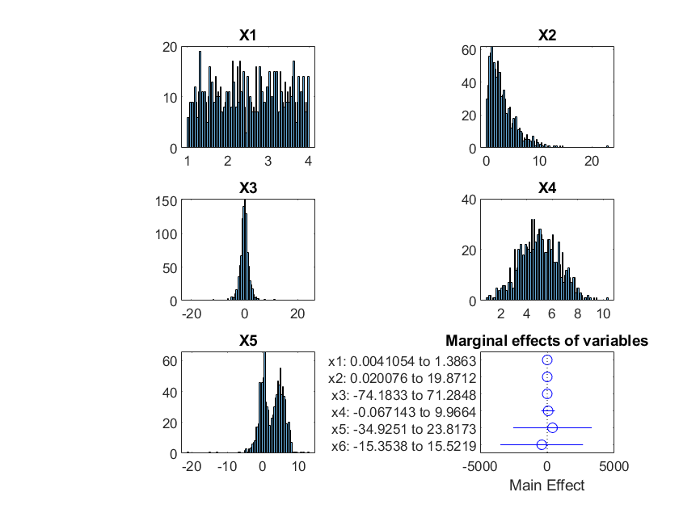

6. Representación de los regresores

```matlab
figure(3)
plotEffects(betas500)
title("Marginal effects of variables")
```

## Seguimiento MatLab

### Parte 1. Distribución

1.Utilizando el output de la funcion de la matriz genere una matriz NN300×6. A partir de ella genere una matriz CC7×6 en la cual las primeras filas detallen la media, la desviación estándar, el mınimo, el maximo, y la mediana de cada columna de NN.

```matlab
nn = xx(300,1)
cc = [mean(nn)' std(nn)'  min(nn)' max(nn)' median(nn)']
```

[output not shown]

### 2 Bucles

1. Genere un bucle (for) que grafique los ejercicios 3.7 y 5.6 de una forma más eficiente.

Para ello cree una función plotxx

2. Genere un programa que:

(a) Genere una matriz HH20×6 con la funcion del ejercicio 3.

```matlab
hh = xx(20,1)
```

(b) Si la suma de los elementos de la fila 1 es par, genere otra matriz. De lo contrario mantenga

```matlab
for n = 1:length(hh)
if sum(hh(1,:)) > 2*n
    xx(20,1)
else
    hh
end
end
```

(c) Genere una matriz ZZ1×i cuya dimension columnas sea dinamica. En cada nuevo loop debe ir agregando un nuevo elemento al final de la fila 1.

```matlab
for i = 1:i+1
zz = xx(1,i)
end
```

(d) Estos elementos se escogeran de esta forma: comenzando con la columna 1, se van tomando los elementos fila a fila, uno por loop. Si se termina la columna, comenzamos con el elemento 1 de la columna 2 etc.

```matlab
for i = 1:i+1
zz = xx(1,i)
select = zz(1,i)
end
```

(e) El proceso de generaci on de la matriz HH debe detenerse cuando la suma de sus elementos alcance el valor 50. Ayuda: busque la funci ́on while.

```matlab
while sum(hh, "all") == 50
for n = 1:length(hh)
if sum(hh(1,:)) > 2*n
    xx(20,1)
else
    hh
end
end
end
```

(f) Finalmente, encuentre y señale la posicion del ultimo elemento agregado en la matriz original HH utilizando una sentencia del tipo “El elemento nrox de la matriz ZZ se encuentra en la posicion r, c en la matriz HH”. Ayuda: busque la funcion disp.

```matlab
while sum(zz, "all") == 50
for i = 1:i+1
zz = xx(1,i)
end
out=double(extract(string(zz),2))';
end
disp(out)
```